# Assignment 2: Exploratory Data Analysis

This assignment covers **Chapters 6-8** from the textbook as well as lecture material from Weeks 3-4. Please complete this assignment by providing answers in cells after the question. Use **Code** cells to write and run any code you need to answer the question and **Markdown** cells to write out answers in words. After you are finished with the assignment, remember to download it as an **HTML file** and submit it in **ELMS** by the specified due date.

```python
import numpy as np
from datascience import *


# These lines do some fancy plotting magic.
import matplotlib
%matplotlib inline
import matplotlib.pyplot as plt

# This is if you want your plots to have the FiveThirtyEight style
plt.style.use('fivethirtyeight')
```

### Question 1. Unemployment

The Federal Reserve Bank of St. Louis publishes data about jobs in the US. Below, we've loaded data on unemployment in the United States. There are many ways of defining unemployment, and our dataset includes two notions of the unemployment rate:

1. Among people who are able to work and are looking for a full-time job, the percentage who can't find a job. This is called the Non-Employment Index, or NEI.
2. Among people who are able to work and are looking for a full-time job, the percentage who can't find any job *or* are only working at a part-time job. The latter group is called "Part-Time for Economic Reasons", so the acronym for this index is NEI-PTER. (Economists are great at marketing.)

The source of the data is [here](https://fred.stlouisfed.org/categories/33509).

**a)** The data are in a CSV file called `unemployment.csv`. Load that file into a table called `unemployment`.

```python
unemployment = Table.read_table('unemployment.csv')
unemployment.show(5)
```

| Date | NEI | NEI-PTER |
| --- | --- | --- |
| 1994-01-01 | 10.0974 | 11.172 |
| 1994-04-01 | 9.6239 | 10.7883 |
| 1994-07-01 | 9.3276 | 10.4831 |
| 1994-10-01 | 9.1071 | 10.2361 |
| 1995-01-01 | 8.9693 | 10.1832 |

... (85 rows omitted)

**b)** It's believed that many people became PTER (recall: "Part-Time for Economic Reasons") in the "Great Recession" of 2008-2009. NEI-PTER is the percentage of people who are unemployed (and counted in the NEI) plus the percentage of people who are PTER. Compute an array containing the percentage of people who were PTER in each quarter. (The first element of the array should correspond to the first row of `unemployment`, and so on.) Call the array `pter`.

```python
nei_create_array = unemployment.column('NEI')
nei_pter_create_array = unemployment.column('NEI-PTER')
pter = nei_pter_create - nei_create
```

**c)** Add `pter` as a column to `unemployment` (named "PTER") and sort the resulting table by that column in descending order. Call this new table `by_pter`.

```python
by_pter = unemployment.with_column("PTER", pter)
by_pter.show(2)
```

| Date | NEI | NEI-PTER | PTER |
| --- | --- | --- | --- |
| 1994-01-01 | 10.0974 | 11.172 | 1.0746 |
| 1994-04-01 | 9.6239 | 10.7883 | 1.1644 |

... (88 rows omitted)

**d)** We want to create a line plot of the PTER over time. To do this, we first add a `year` array and the `pter` array to the `unemployment` table labeled `Year` and `PTER`, respectively. Use the code below to create `pter_over_time`.

```python
# Make sure your previous sections have created by_pter and pter properly for this to work!
year = 1994 + np.arange(by_pter.num_rows)/4
```

```python
pter_over_time = unemployment.with_columns('Year', year,'PTER',pter)
```

Create a line plot using `pter_over_time`.

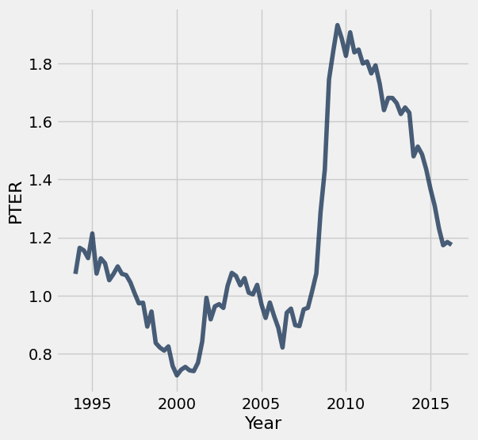

```python
pter_over_time.plot('Year', 'PTER')
```

**e)** Were PTER rates high during or directly after the Great Recession (that is to say, were PTER rates particularly high in the years 2008 through 2011)?

Yes, the line graph show that there was a upward trending spike in PTER rates from 2008 to 2011.

### Question 2. Cards Against Humanity - Pulse of the Nation Public Opinion Poll

In this question, we'll explore the Cards Against Humanity poll dataset further using the tools we've learned. For your convenience, we have made a subset of the data available to you in a CSV file called `201709-CAH_PulseOfTheNation.csv`.

```python
cah = Table.read_table('201709-CAH_PulseOfTheNation.csv')
```

**a)** Create a contingency table with the frequencies of people who believe in ghosts and level of education, with `Believe in Ghosts` going across the top and `Level of Education` on the side. Assign the table to `ghosts_by_education`.

```python
ghosts_by_education = cah.pivot('Level of Education', 'Believe in Ghosts')
ghosts_by_education.show(3)
```

| Believe in Ghosts | College degree | Graduate degree | High school | Other | Some college |
| --- | --- | --- | --- | --- | --- |
| DK/REF | 1 | 5 | 0 | 0 | 2 |
| No | 68 | 49 | 33 | 1 | 36 |
| Yes | 37 | 26 | 21 | 4 | 27 |

**b)** Use the `ghosts_by_education` table to create an appropriate visualization.

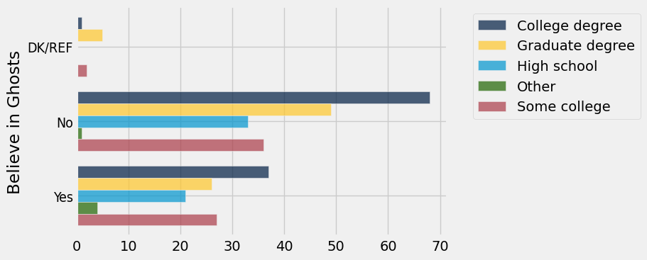

```python
ghosts_by_education.barh('Believe in Ghosts')
```

**c)** Run the following cell and explain what it does. What does the `percents()` function do? What does the `distributions` table represent?

*Note:* Make sure you set up the `ghosts_by_education` table properly in part d. You might need to change the order of variables.

```python
def percents(array_x):
    return np.round( (array_x/sum(array_x))*100, 2)

labels = ghosts_by_education.labels

distributions = Table().with_columns(labels[0], ghosts_by_education.column(0),
                                     labels[1], percents(ghosts_by_education.column(1)),
                                     labels[2], percents(ghosts_by_education.column(2)),
                                     labels[3], percents(ghosts_by_education.column(3)))
distributions.show()
```

| Believe in Ghosts | College degree | Graduate degree | High school |
| --- | --- | --- | --- |
| DK/REF | 0.94 | 6.25 | 0 |
| No | 64.15 | 61.25 | 61.11 |
| Yes | 34.91 | 32.5 | 38.89 |

**d)** Do people who are less educated tended to believe in ghosts more? Use the summaries and visualizations you found above to justify your answer.

Yes, people who are less educated tend to believe in ghosts. The bar graph shows that people who answered no to believing were mostly college educated or had some college.

**e)** Write a function called `is_not_zero` which takes one argument and returns `True` if that value isn't 0 and `False` if the value is 0.

```python
ghosts_by_education.show(3)
```

| Believe in Ghosts | College degree | Graduate degree | High school | Other | Some college |
| --- | --- | --- | --- | --- | --- |
| DK/REF | 1 | 5 | 0 | 0 | 2 |
| No | 68 | 49 | 33 | 1 | 36 |
| Yes | 37 | 26 | 21 | 4 | 27 |

**f)** The variable `Transformers Movies` has the number of Transformers movies that the respondent saw in the past year. Add a new column to `cah` called "Transformers" which is `True` if the person has watched any Transformers movies and `False` if they haven't.

```python
def movies(num):
    if num == 0:
        return False
    else:
        return True

transform_movies = cah.apply(movies, "Transformer Movies")
trans_formers = cah.with_column("Transformer Movies", transform_movies)
transformer_watcher = trans_formers.where("Transformer Movies", are.equal_to(True))
not_transformer_watcher = trans_formers.where("Transformer Movies", are.equal_to(False))
not_transformer_watcher
```

| Income | Gender | Age | Age Range | Political Affiliation | Transformer Movies | Level of Education | Believe in Ghosts |
| --- | --- | --- | --- | --- | --- | --- | --- |
| 68000 | Female | 56 | 55-64 | Democrat | False | High school | No |
| 46000 | Male | 63 | 55-64 | Independent | False | Some college | No |
| 51000 | Male | 48 | 45-54 | Republican | False | High school | No |
| 54000 | Female | 64 | 55-64 | Democrat | False | Some college | No |
| 83000 | Male | 61 | 55-64 | Independent | False | College degree | Yes |
| 90000 | Female | 64 | 55-64 | Republican | False | High school | No |
| 5000 | Female | 68 | 65+ | Democrat | False | Some college | No |
| 57000 | Female | 63 | 55-64 | Democrat | False | College degree | No |
| 39000 | Female | 57 | 55-64 | Democrat | False | College degree | Yes |
| 5000 | Female | 62 | 55-64 | Democrat | False | College degree | No |

... (144 rows omitted)

**g)** How many people have watched any Transformers movies? How many have not?

The number of people who have watch any Transformer Movies are 156 and the number of people who have not watched any Transformer Movies are 154.

**h)** Is there a relationship between level of education and having watched at least one Transformers movie? Use the same analysis as in parts a-c to answer the question.

```python
transformers_by_edu = cah.pivot('Level of Education', 'Transformer Movies')
```

```python
def percents(array_x):
    return np.round( (array_x/sum(array_x))*100, 2)

label = transformers_by_edu.labels

dist = Table().with_columns(label[0], transformers_by_edu.column(0),
                                     label[1], percents(transformers_by_edu.column(1)),
                                     label[2], percents(transformers_by_edu.column(2)),
                                     label[3], percents(transformers_by_edu.column(3)))
dist.show()
```

| Transformer Movies | College degree | Graduate degree | High school |
| --- | --- | --- | --- |
| 0 | 56.6 | 47.5 | 40.74 |
| 1 | 8.49 | 27.5 | 22.22 |
| 2 | 14.15 | 6.25 | 7.41 |
| 3 | 10.38 | 8.75 | 12.96 |
| 4 | 3.77 | 3.75 | 9.26 |
| 5 | 6.6 | 6.25 | 7.41 |

It seems that people with an education had seen the least amount of Transformer Movies.